# Benchmarking rcrisp across European city-river cases

This vignette documents how `rcrisp` performs across a diverse set of European city-river cases. The goal is to identify which pipeline steps are most computationally intensive and how run time varies with the scale and complexity of the urban river system being delineated.

Benchmarks were run on a single machine in a single session using OSM and SRTM data downloaded live; the `get_osm()` and `get_dem()` timings therefore include network latency and reflect the volume of spatial data available for each case, not just CPU work.

```r
library(dplyr)
library(ggplot2)
```

## Cases

```r
raw <- read.csv(
  system.file("extdata", "benchmark_timings.csv", package = "rcrisp"),
  stringsAsFactors = FALSE
)

# Pipeline steps in processing order
io_steps      <- c("get_osm", "get_dem")
compute_steps <- c("delineate_valley", "as_network", "delineate_corridor",
                   "delineate_segments", "delineate_riverspace")
all_steps     <- c(io_steps, compute_steps)

step_labels <- c(
  get_osm              = "get_osm()",
  get_dem              = "get_dem()",
  delineate_valley     = "delineate_valley()",
  as_network           = "as_network()",
  delineate_corridor   = "delineate_corridor()",
  delineate_segments   = "delineate_segments()",
  delineate_riverspace = "delineate_riverspace()"
)

raw <- raw |>
  mutate(case = paste0(city_name, " (", river_name, ")"))

# Cases that completed the full pipeline
case_order <- raw |>
  filter(step == "total", status == "success") |>
  arrange(elapsed_s) |>
  pull(case)
```

The table below summarises the 36 city-river cases included in the benchmark. Cases marked *Incomplete* did not produce a final delineation; the step at which the run was interrupted is shown in the *Note* column.

[output not shown]

## Run time by case

The chart below shows total run time per case, broken into **data download** (`get_osm()` + `get_dem()`) and **computation** (all delineation steps). Only the 31 cases that completed the full pipeline are included. Cases are sorted from fastest (bottom) to slowest (top).

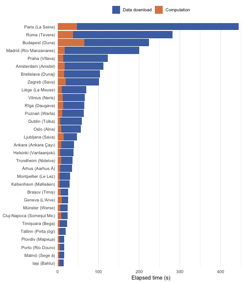

```r
bar_data <- raw |>
  filter(case %in% case_order, step %in% all_steps, status == "success") |>
  mutate(
    step_type = if_else(step %in% io_steps, "Data download", "Computation"),
    case = factor(case, levels = case_order)
  ) |>
  group_by(case, step_type) |>
  summarise(elapsed_s = sum(elapsed_s), .groups = "drop") |>
  mutate(step_type = factor(step_type, levels = c("Data download", "Computation")))

ggplot(bar_data, aes(x = elapsed_s, y = case, fill = step_type)) +
  geom_bar(stat = "identity") +
  scale_x_continuous(expand = expansion(mult = c(0, 0.03))) +
  scale_fill_manual(
    values = c("Data download" = "#4C72B0", "Computation" = "#DD8452"),
    breaks = c("Data download", "Computation")
  ) +
  labs(
    x    = "Elapsed time (s)",
    y    = NULL,
    fill = NULL
  ) +
  theme_minimal(base_size = 11) +
  theme(
    legend.position       = "top",
    panel.grid.major.y    = element_blank()
  )
```

Data download accounts for the majority of wall-clock time in most cases. The variation in `get_osm()` time is driven primarily by the volume of OSM data within the area of interest: large metropolitan areas (Paris, Roma, Budapest) have substantially more street and building data than smaller or less densely documented cities.